# Capsule 6 - Communiquer l’incertitude

MQT-2101 - Analyse et modélisation des données

## Pourquoi ça compte

Une seule valeur suffit-elle au suivi énergétique?

Une prévision ponctuelle ne décrit pas l’incertitude autour des besoins mensuels en énergie.

## Objectifs de la capsule

- Distinguer point et intervalle.
- Lire un cône de prédiction.
- Nommer les hypothèses qui limitent l’intervalle.

## Un point et une plage

Point

Une valeur prévue

Intervalle

Une plage avec un niveau nominal

## Interpréter 95 %

Sur des répétitions comparables, une procédure calibrée à 95 % couvre la future observation dans environ 95 % des cas.

## Une approximation normale

$$\widehat y_{T+h\mid T}\ \pm\ 1{,}96\,\widehat\sigma_h.$$

Pour 95 %, si l’approximation normale et l’écart-type prédictif sont appropriés.

## Plus loin, plus incertain?

Niveau nominal plus élevé

intervalle généralement plus large

Horizon plus lointain

incertitude souvent accrue

## Lire un cône de prédiction

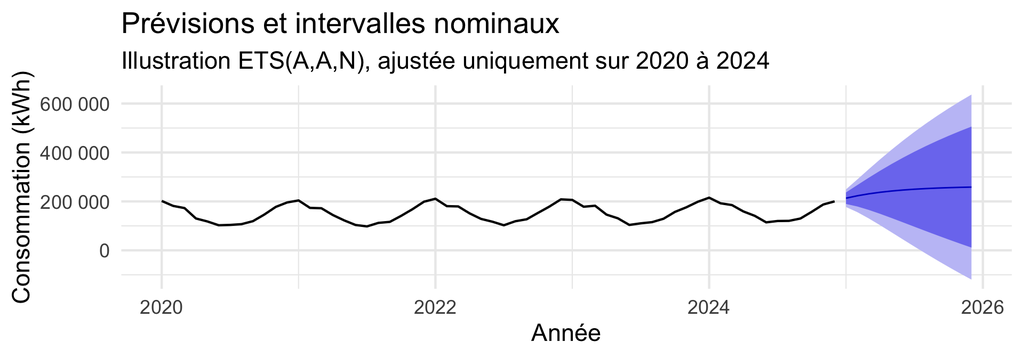

À h = 12, la borne à 95 % devient négative : limite du modèle pour une consommation d’énergie.

## Lire les trois lettres ETS

E

type d’erreur

T

type de tendance

S

type de saisonnalité

A : additif. M : multiplicatif. N : absence de tendance ou saisonnalité. Z : choix automatique dans forecast::ets().

## Comparer des cônes sans choisir à l’œil

ANN, AAN, AAA

trois structures illustratives

Validation

comparer erreurs et couverture

## Relier l’intervalle à une décision

Capacité

risque de dépassement

Budget

marge et scénario défavorable

## À retenir

Point

une prévision centrale

Plage

un niveau nominal

Limite

hypothèses et contexte

## Production autonome 6.6

Produisez le cône ETS(A,A,N) à l’origine de décembre 2024. Comparez les intervalles à 80 % et 95 % pour h = 1 et h = 12. Expliquez son usage et une limite.

### Auto-vérification

- J’ai nommé l’origine, l’horizon et le niveau de chaque intervalle.
- J’ai comparé les intervalles à 80 % et 95 % pour les horizons de un et douze mois.
- J’ai expliqué un usage et une limite sans annoncer une certitude ni la couverture de toute la trajectoire.